# Reporte Previo

09/12/2017

## Indicadores de violación en la adolescencia

- Endireh 2016
- Envipe 2017
- Envin 2007
- Nacimientos 2010 a 2016
- Censo Nacional de Procuración de Justicia Estatal 2010 a 2016

#### Bases

Total mujeres mayores de 15 años en 2016 (ENDIREH 2016): 46,501,740

Total población mayor de 18 años en 2016 (ENVIPE 2017): 83,888,403. De los que 44,559,065 son mujeres.

Total mujeres entre 15 años y 24 años en 2007 (ENVIN 2007): 14,061,802

### Generales

De acuerdo a la ENVIPE 2017 el 0.06% de la población mayor de edad sufrió una violación sexual durante 2016. El 0.02% (6,054) de los hombres sufrió una violación. De mujeres el 0.1% (43,874) fueron agredidas.

La proporción de violaciones por sexo:

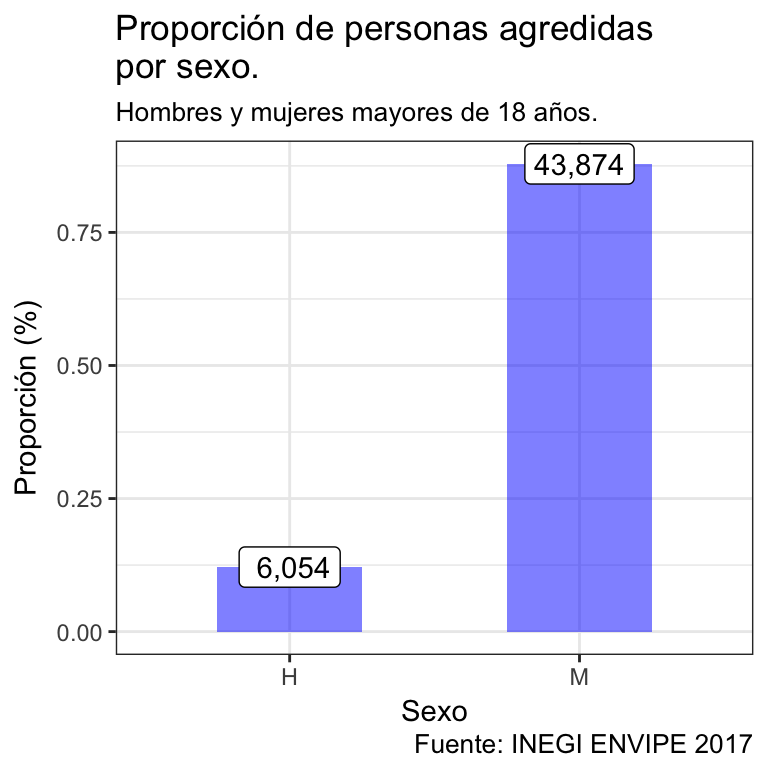

De estas mujeres, la distribución de edad de la primera vez de abuso es la siguiente:

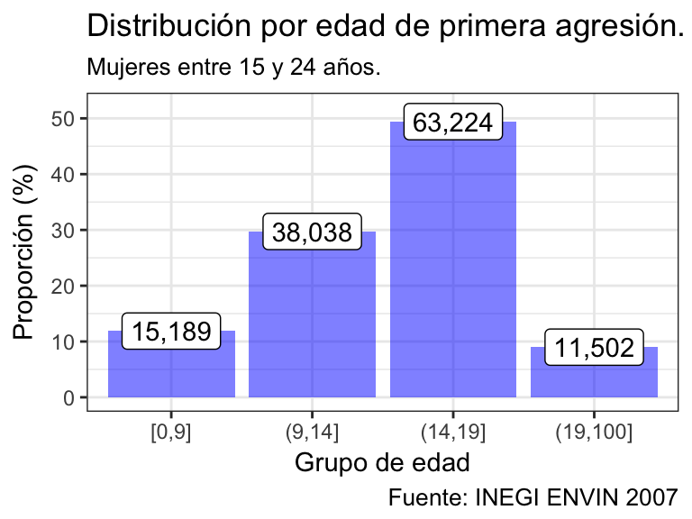

De acuerdo a ENDIREH 2016 el 3.4% (1,565,609) de las mujeres (46,501,740) fueron agredidas alguna vez en su vida. Esta cifra puede estar sub estimada dado que se descarta la pregunta sobre agresión en pareja porque incluye abuso sexual con intento de abuso sexual.

### Adolescencia Temprana

Proporción de mujeres agredidas antes de los 15 años. Fuente: INEGI ENDIREH 2016

| Agresión antes de 15 años | Frec ponderada | Frec muestra | % ponderado |
| --- | --- | --- | --- |
| Sí | 1175865 | 2922 | 2.53 |
| No | 42698753 | 102377 | 91.82 |
| No recuerda | 2627122 | 5957 | 5.65 |

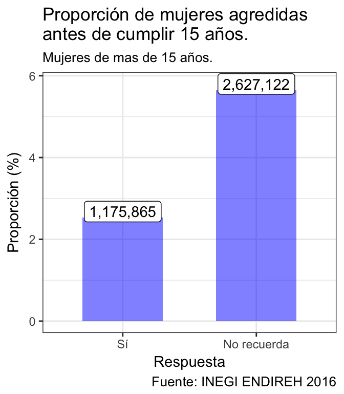

Pregunta: *Durante su infancia (hasta antes de cumplir 15 años), ¿dígame si vivió o le ocurrieron algunas de las situaciones que se mencionan en la tarjeta? ¿La obligaron a tener relaciones sexuales bajo amenazas o usando la fuerza?*

### Adolescencia Tardía

De acuerdo a ENDIREH 2016, el 1.7448957% (95,689) de las mujeres entrevistadas de 15 a 19 años (5,483,938) han sido obligadas a tener relaciones sexuales alguna vez en su vida o su pareja ha intentado obligarlas en algún momento.

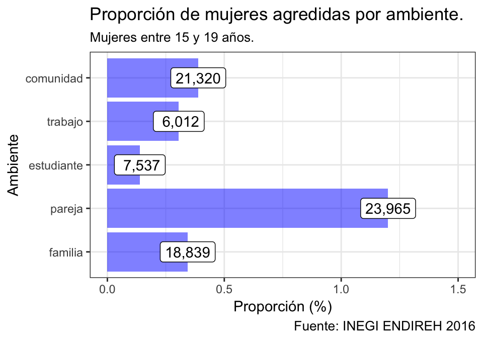

Preguntas: *- Estudiante: Durante su vida de estudiante, ¿alguna persona de las escuelas a las que asistió a estudiar, (como maestra o maestro, director, prefecto, compañero de clase o alumno de la escuela u otro trabajador o persona de la escuela) la han obligado a tener relaciones sexuales en contra de su voluntad? - Trabajo: Dígame si en alguno de sus trabajos, ¿Alguna o algunas personas que trabajaban con usted la han obligado a tener relaciones sexuales en contra de su voluntad? - Comunidad: ¿Alguna vez la han obligado a tener relaciones sexuales en contra de su voluntad? - Familia: Durante el último año, de octubre de 2015 a la fecha, ¿alguna o algunas personas de su familia (no incluya a su pareja o esposo) la han obligado a tener relaciones sexuales en contra de su voluntad - Pareja: ¿Alguna de sus parejas o esposo(s) anteriores, ¿durante su relación o después de separarse la agredió sexualmente (intentó obligarla o la obligó a tener relaciones sexuales por la fuerza o con amenazas)?*

## Otras Referencias

En esta sección se presentas indicadores alternativos de contexto. La fuente de información es la encuesta ENDIREH 2016.

**Edad de la madre al tener el primer hijo.**

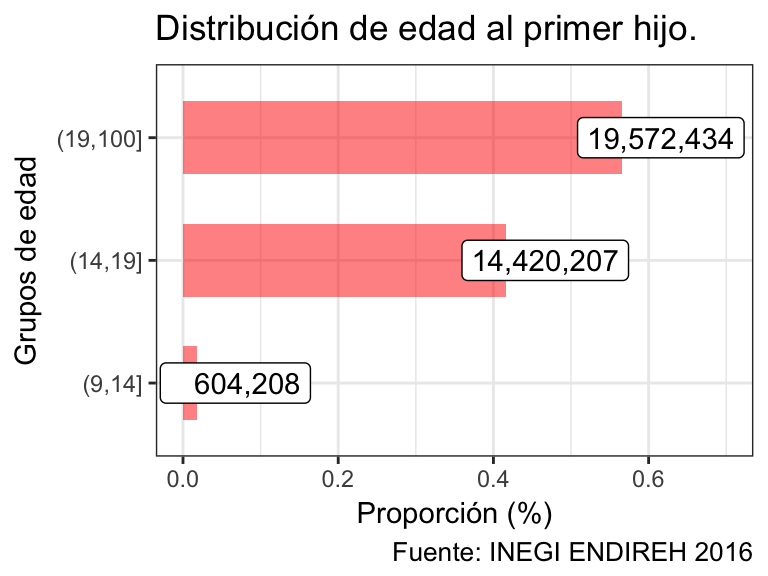

Distribución de edad de mujeres al primer hijo. Fuente: INEGI ENDIREH 2016

| Grupo de edad de la mujer | Frecuencia muestral | Frecuencia ponderada | % ponderado |
| --- | --- | --- | --- |
| (9,14] | 1681 | 604208 | 1.75 |
| (14,19] | 38143 | 14420207 | 41.68 |
| (19,100] | 50404 | 19572434 | 56.57 |

**Edad y consentimiento de la mujer en la primera relación sexual por edad.**

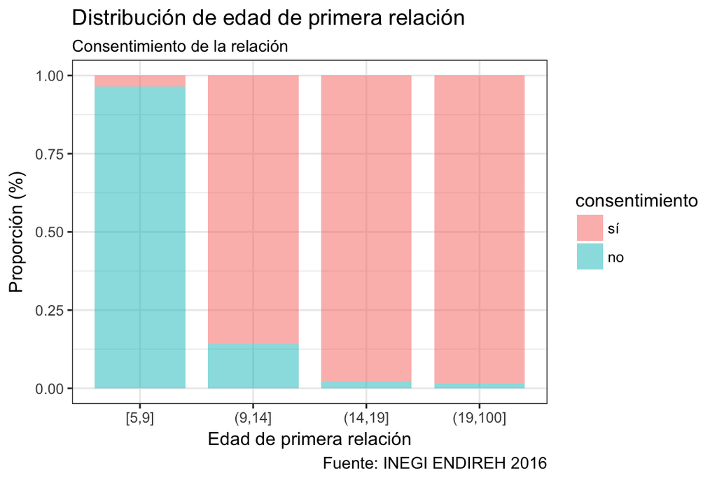

| Consentimiento | Edad de primera relación | Frecuencia muestral | Frecuencia ponderada | % ponderado |
| --- | --- | --- | --- | --- |
| sí | [5,9] | 16 | 6982 | 3.55 |
| sí | (9,14] | 6406 | 2420519 | 85.98 |
| sí | (14,19] | 56313 | 22641596 | 98.02 |
| sí | (19,100] | 35696 | 14094795 | 98.71 |
| no | [5,9] | 493 | 189736 | 96.45 |
| no | (9,14] | 977 | 394534 | 14.02 |
| no | (14,19] | 1072 | 457772 | 1.98 |
| no | (19,100] | 439 | 184032 | 1.29 |

*Preguntas: - P12_6: ¿Cuántos años tenía usted cuando tuvo su primera relación sexual? - P12_7: ¿Esta primera experiencia fue con su consentimiento (usted así lo quiso)?*

**Edad de la mujer al momento de la primera unión o matrimonio.**

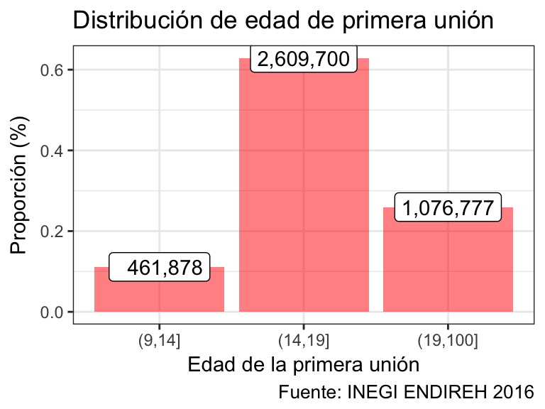

Distribución de edad de mujeres en la primera unión. Fuente: INEGI ENDIREH 2016

| Edad de primera unión | Frecuencia muestral | Frecuencia ponderada | % ponderado |
| --- | --- | --- | --- |
| (9,14] | 1302 | 461878 | 11.13 |
| (14,19] | 7419 | 2609700 | 62.91 |
| (19,100] | 3077 | 1076777 | 25.96 |

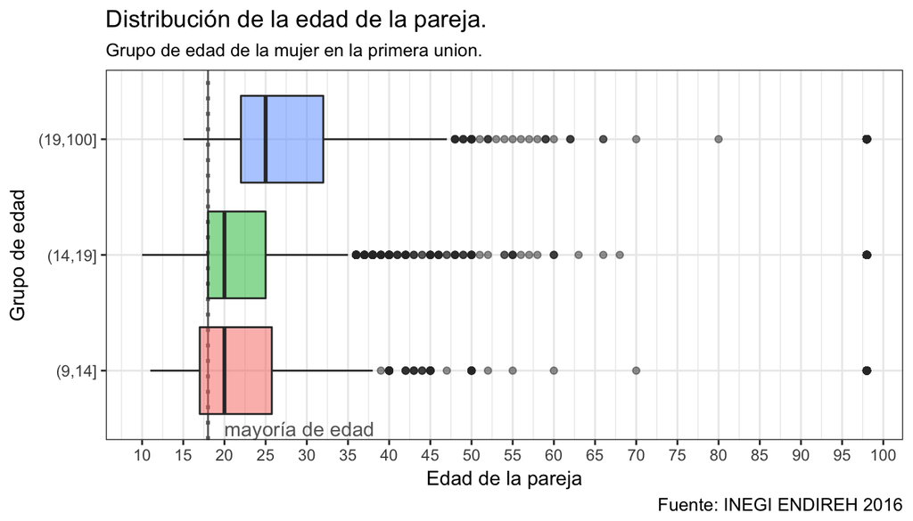

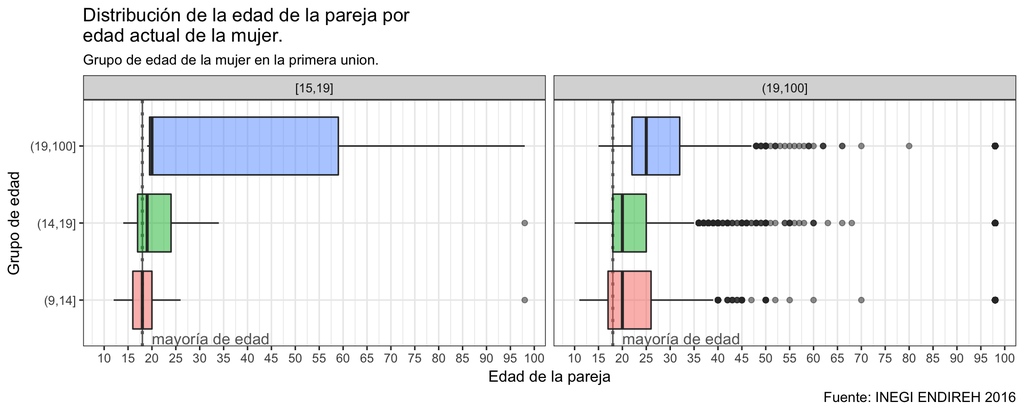

**Razones de union/matrimonio actual.**

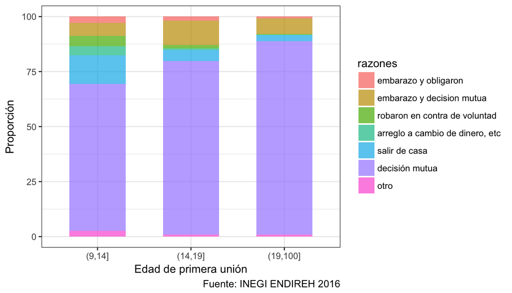

Distribución de razones de unión por edad de mujeres en la primera unión. Fuente: INEGI ENDIREH 2016

| Edad de primera unión | Razones de unión | Frecuencia ponderada | Frecuencia muestral | % ponderado |
| --- | --- | --- | --- | --- |
| (9,14] | embarazo y obligaron | 29460 | 64 | 2.91 |
| (9,14] | embarazo y decision mutua | 60110 | 167 | 5.93 |
| (9,14] | robaron en contra de voluntad | 46194 | 128 | 4.56 |
| (9,14] | arreglo a cambio de dinero, etc | 42979 | 110 | 4.24 |
| (9,14] | salir de casa | 132546 | 361 | 13.07 |
| (9,14] | decisión mutua | 675892 | 1939 | 66.65 |
| (9,14] | otro | 26885 | 79 | 2.65 |
| (14,19] | embarazo y obligaron | 246884 | 580 | 1.75 |
| (14,19] | embarazo y decision mutua | 1581227 | 3627 | 11.22 |
| (14,19] | robaron en contra de voluntad | 204330 | 473 | 1.45 |
| (14,19] | arreglo a cambio de dinero, etc | 99194 | 245 | 0.70 |
| (14,19] | salir de casa | 721123 | 1938 | 5.12 |
| (14,19] | decisión mutua | 11103672 | 29817 | 78.80 |
| (14,19] | otro | 133708 | 324 | 0.95 |
| (19,100] | embarazo y obligaron | 146811 | 337 | 0.74 |
| (19,100] | embarazo y decision mutua | 1419069 | 3439 | 7.11 |
| (19,100] | robaron en contra de voluntad | 88438 | 211 | 0.44 |
| (19,100] | arreglo a cambio de dinero, etc | 42517 | 115 | 0.21 |
| (19,100] | salir de casa | 523698 | 1331 | 2.62 |
| (19,100] | decisión mutua | 17547043 | 46691 | 87.90 |
| (19,100] | otro | 195150 | 469 | 0.98 |

## Denuncias

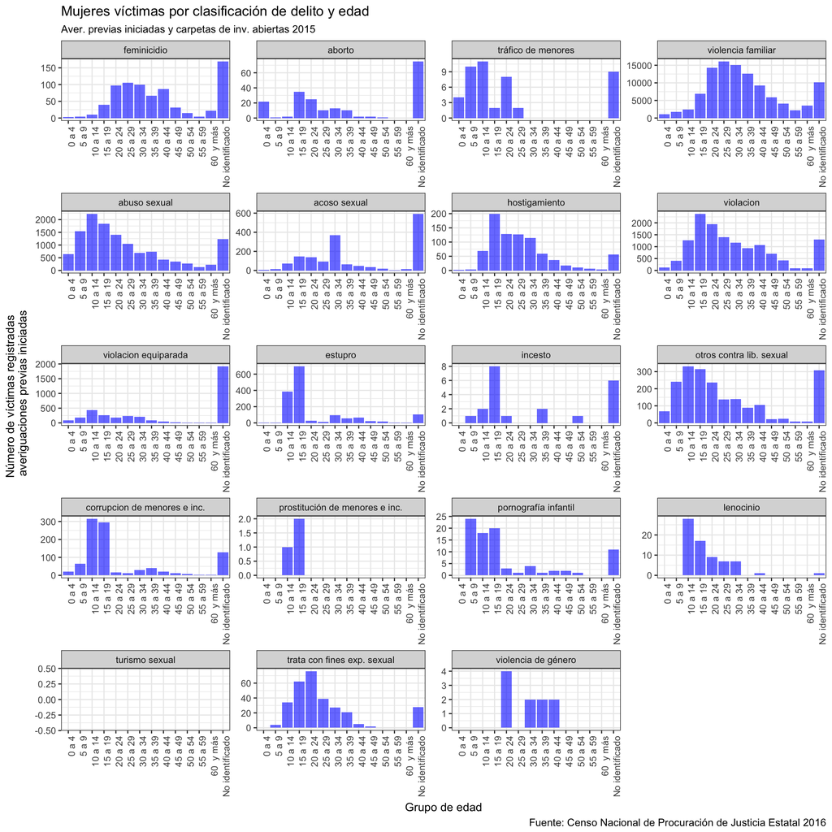

Número de víctimas mujeres por edad y delito. Fuente: Censo Nacional de Procuración de Justicia Estatal 2016

| Edad de víctima | Delito | Frecuencia | % por edad | % por delito |
| --- | --- | --- | --- | --- |
| 0 a 4 | feminicidio | 3 | 0.14 | 0.40 |
| 0 a 4 | aborto | 22 | 1.06 | 11.11 |
| 0 a 4 | tráfico de menores | 4 | 0.19 | 8.70 |
| 0 a 4 | violencia familiar | 1082 | 52.07 | 1.03 |
| 0 a 4 | abuso sexual | 650 | 31.28 | 5.09 |
| 0 a 4 | acoso sexual | 5 | 0.24 | 0.31 |
| 0 a 4 | hostigamiento | 2 | 0.10 | 0.24 |
| 0 a 4 | violacion | 133 | 6.40 | 1.00 |
| 0 a 4 | violacion equiparada | 85 | 4.09 | 2.32 |
| 0 a 4 | estupro | 3 | 0.14 | 0.20 |
| 0 a 4 | incesto | 0 | 0.00 | 0.00 |
| 0 a 4 | otros contra lib. sexual | 69 | 3.32 | 3.39 |
| 0 a 4 | corrupcion de menores e inc. | 20 | 0.96 | 2.06 |
| 0 a 4 | prostitución de menores e inc. | 0 | 0.00 | 0.00 |
| 0 a 4 | pornografía infantil | 0 | 0.00 | 0.00 |
| 0 a 4 | lenocinio | 0 | 0.00 | 0.00 |
| 0 a 4 | turismo sexual | 0 | 0.00 | NaN |
| 0 a 4 | trata con fines exp. sexual | 0 | 0.00 | 0.00 |
| 0 a 4 | violencia de género | 0 | 0.00 | 0.00 |
| 5 a 9 | feminicidio | 4 | 0.09 | 0.53 |
| 5 a 9 | aborto | 1 | 0.02 | 0.51 |
| 5 a 9 | tráfico de menores | 10 | 0.23 | 21.74 |
| 5 a 9 | violencia familiar | 1765 | 41.34 | 1.68 |
| 5 a 9 | abuso sexual | 1549 | 36.28 | 12.14 |
| 5 a 9 | acoso sexual | 14 | 0.33 | 0.86 |
| 5 a 9 | hostigamiento | 3 | 0.07 | 0.36 |
| 5 a 9 | violacion | 402 | 9.42 | 3.02 |
| 5 a 9 | violacion equiparada | 185 | 4.33 | 5.04 |
| 5 a 9 | estupro | 1 | 0.02 | 0.07 |
| 5 a 9 | incesto | 1 | 0.02 | 4.76 |

[output cut: 236 more lines]

Número de víctimas por sexo, edad y delito. Fuente: Censo Nacional de Procuración de Justicia Estatal 2016

| Sexo de víctima | Edad de víctima | Delito | Frecuencia por sexo | % por edad | % por delito |
| --- | --- | --- | --- | --- | --- |
| Muj | 0 a 4 | feminicidio | 3 | 0.14 | 0.40 |
| Muj | 0 a 4 | aborto | 22 | 1.06 | 8.12 |
| Muj | 0 a 4 | tráfico de menores | 4 | 0.19 | 5.26 |
| Muj | 0 a 4 | violencia familiar | 1082 | 52.07 | 0.81 |
| Muj | 0 a 4 | abuso sexual | 650 | 31.28 | 3.91 |
| Muj | 0 a 4 | acoso sexual | 5 | 0.24 | 0.29 |
| Muj | 0 a 4 | hostigamiento | 2 | 0.10 | 0.19 |
| Muj | 0 a 4 | violacion | 133 | 6.40 | 0.82 |
| Muj | 0 a 4 | violacion equiparada | 85 | 4.09 | 2.12 |
| Muj | 0 a 4 | estupro | 3 | 0.14 | 0.18 |
| Muj | 0 a 4 | incesto | 0 | 0.00 | 0.00 |
| Muj | 0 a 4 | otros contra lib. sexual | 69 | 3.32 | 2.91 |
| Muj | 0 a 4 | corrupcion de menores e inc. | 20 | 0.96 | 1.20 |
| Muj | 0 a 4 | prostitución de menores e inc. | 0 | 0.00 | 0.00 |
| Muj | 0 a 4 | pornografía infantil | 0 | 0.00 | 0.00 |
| Muj | 0 a 4 | lenocinio | 0 | 0.00 | 0.00 |
| Muj | 0 a 4 | turismo sexual | 0 | 0.00 | NaN |
| Muj | 0 a 4 | trata con fines exp. sexual | 0 | 0.00 | 0.00 |
| Muj | 0 a 4 | violencia de género | 0 | 0.00 | 0.00 |
| Muj | 5 a 9 | feminicidio | 4 | 0.09 | 0.53 |
| Muj | 5 a 9 | aborto | 1 | 0.02 | 0.37 |
| Muj | 5 a 9 | tráfico de menores | 10 | 0.23 | 13.16 |
| Muj | 5 a 9 | violencia familiar | 1765 | 41.34 | 1.32 |
| Muj | 5 a 9 | abuso sexual | 1549 | 36.28 | 9.32 |
| Muj | 5 a 9 | acoso sexual | 14 | 0.33 | 0.81 |
| Muj | 5 a 9 | hostigamiento | 3 | 0.07 | 0.28 |
| Muj | 5 a 9 | violacion | 402 | 9.42 | 2.46 |
| Muj | 5 a 9 | violacion equiparada | 185 | 4.33 | 4.61 |
| Muj | 5 a 9 | estupro | 1 | 0.02 | 0.06 |
| Muj | 5 a 9 | incesto | 1 | 0.02 | 4.35 |

[output cut: 502 more lines]

## Natalidad

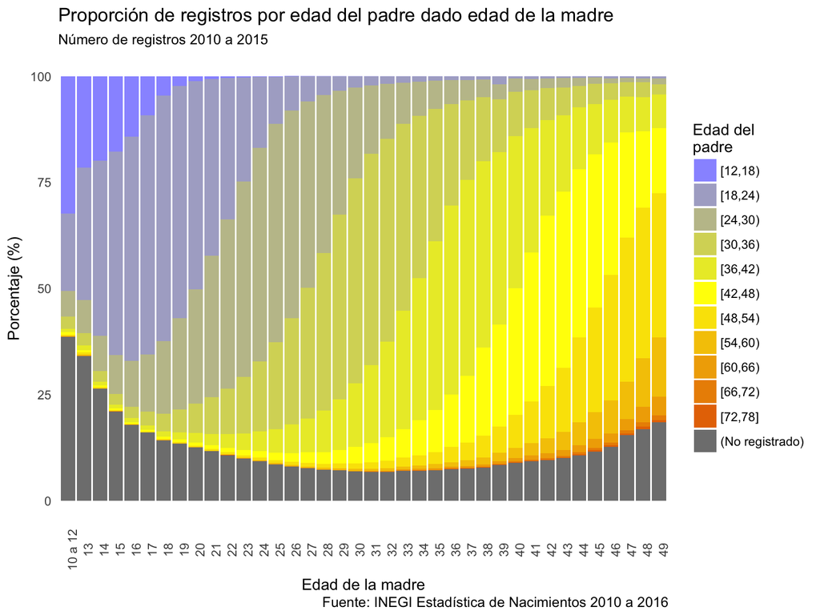

Distribución de edad del padre por año de edad de la madre. Fuente: INEGI Estadística de Nacimientos 2010 a 2016

| Edad de madre | Edad de padre | Frecuencia | % por edad madre |
| --- | --- | --- | --- |
| 10 a 12 | [12,18) | 2177 | 32.42 |
| 10 a 12 | [18,24) | 1221 | 18.19 |
| 10 a 12 | [24,30) | 405 | 6.03 |
| 10 a 12 | [30,36) | 190 | 2.83 |
| 10 a 12 | [36,42) | 59 | 0.88 |
| 10 a 12 | [42,48) | 36 | 0.54 |
| 10 a 12 | [48,54) | 19 | 0.28 |
| 10 a 12 | [54,60) | 9 | 0.13 |
| 10 a 12 | [60,66) | 5 | 0.07 |
| 10 a 12 | [66,72) | 1 | 0.01 |
| 10 a 12 | [72,78] | 4 | 0.06 |
| 10 a 12 | (No registrado) | 2588 | 38.55 |
| 13 | [12,18) | 2559 | 21.52 |
| 13 | [18,24) | 3715 | 31.24 |
| 13 | [24,30) | 924 | 7.77 |
| 13 | [30,36) | 349 | 2.93 |
| 13 | [36,42) | 132 | 1.11 |
| 13 | [42,48) | 66 | 0.55 |
| 13 | [48,54) | 52 | 0.44 |
| 13 | [54,60) | 28 | 0.24 |
| 13 | [60,66) | 11 | 0.09 |
| 13 | [66,72) | 5 | 0.04 |
| 13 | [72,78] | 3 | 0.03 |
| 13 | (No registrado) | 4048 | 34.04 |
| 14 | [12,18) | 11383 | 19.88 |
| 14 | [18,24) | 23640 | 41.30 |
| 14 | [24,30) | 4739 | 8.28 |
| 14 | [30,36) | 1414 | 2.47 |
| 14 | [36,42) | 533 | 0.93 |
| 14 | [42,48) | 248 | 0.43 |

[output cut: 424 more lines]

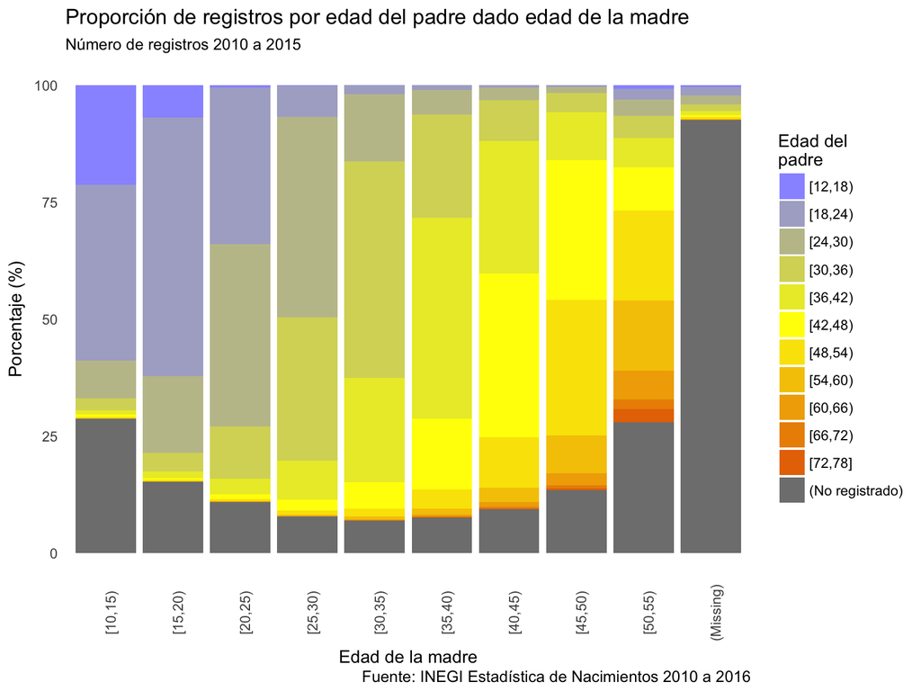

Distribución de edad del padre por quinquenio de edad de la madre. Fuente: INEGI Estadística de Nacimientos 2010 a 2016

| Edad de madre | Edad de padre | Frecuencia | % por edad madre |
| --- | --- | --- | --- |
| [10,15) | [12,18) | 16119 | 21.25 |
| [10,15) | [18,24) | 28576 | 37.67 |
| [10,15) | [24,30) | 6068 | 8.00 |
| [10,15) | [30,36) | 1953 | 2.57 |
| [10,15) | [36,42) | 724 | 0.95 |
| [10,15) | [42,48) | 350 | 0.46 |
| [10,15) | [48,54) | 185 | 0.24 |
| [10,15) | [54,60) | 87 | 0.11 |
| [10,15) | [60,66) | 39 | 0.05 |
| [10,15) | [66,72) | 17 | 0.02 |
| [10,15) | [72,78] | 14 | 0.02 |
| [10,15) | (No registrado) | 21719 | 28.63 |
| [15,20) | [12,18) | 212584 | 6.90 |
| [15,20) | [18,24) | 1703880 | 55.29 |
| [15,20) | [24,30) | 506030 | 16.42 |
| [15,20) | [30,36) | 124286 | 4.03 |
| [15,20) | [36,42) | 40835 | 1.33 |
| [15,20) | [42,48) | 14586 | 0.47 |
| [15,20) | [48,54) | 6069 | 0.20 |
| [15,20) | [54,60) | 2546 | 0.08 |
| [15,20) | [60,66) | 981 | 0.03 |
| [15,20) | [66,72) | 373 | 0.01 |
| [15,20) | [72,78] | 202 | 0.01 |
| [15,20) | (No registrado) | 469222 | 15.23 |
| [20,25) | [12,18) | 28518 | 0.57 |
| [20,25) | [18,24) | 1683186 | 33.42 |
| [20,25) | [24,30) | 1965850 | 39.04 |
| [20,25) | [30,36) | 558531 | 11.09 |
| [20,25) | [36,42) | 166050 | 3.30 |
| [20,25) | [42,48) | 55220 | 1.10 |

[output cut: 90 more lines]

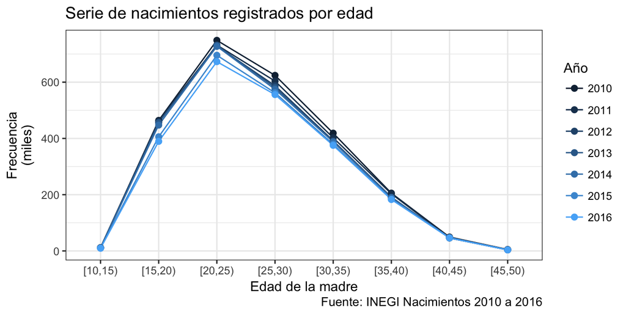

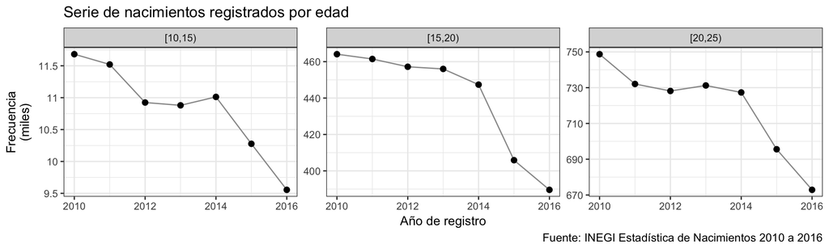

## Estado Civil

Mujeres de 15 a 19 años. Fuente: ENDIREH 2016.

| Estado civil | Frec ponderada | Frec muestral | % pond |
| --- | --- | --- | --- |
| union libre | 612761 | 1313 | 11.17 |
| separada | 63521 | 115 | 1.16 |
| divorciada | 925 | 2 | 0.02 |
| viuda | 525 | 1 | 0.01 |
| casada | 133192 | 303 | 2.43 |
| soltera | 4673014 | 7264 | 85.21 |

## Abandono escolar

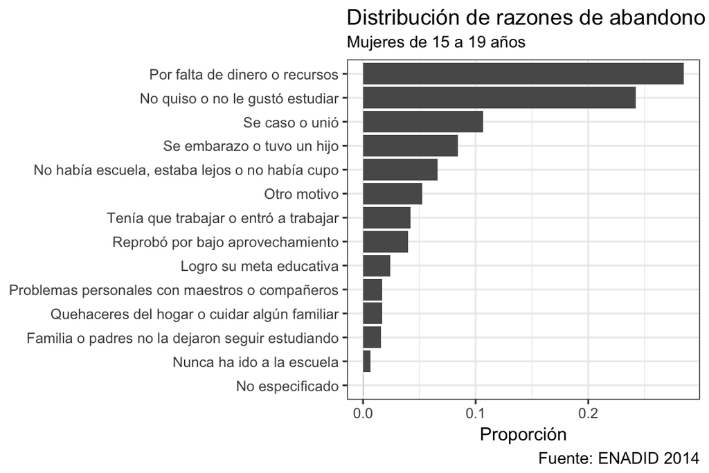